# How can velocity blow up while energy stays bounded?

A taller peak, a smaller region, and the geometry that connects them

Published

September 11, 2026

**A velocity can become arbitrarily large while the energy associated with its shrinking core decreases.** The reason is that kinetic energy depends on both the speed and the amount of fluid moving at that speed. If the region of intense motion shrinks sufficiently quickly, its decreasing volume can outweigh the increasing speed squared.

This is one of the most useful ideas to understand in the proposed OpenAI Navier–Stokes construction. The paper describes unbounded velocity near a finite time while the full flow’s kinetic energy remains uniformly bounded. Its leading core has an even more striking property: the energy in that narrowing region tends to zero. To see why those statements can coexist, we need to look at the geometry as carefully as the velocity. [OpenAI, Theorem 1.1 and Section 2.1](https://cdn.openai.com/pdf/32d9f210-8b73-45e0-91bc-82a30aef8a9a/navier-stokes.pdf)

We will start with an ordinary function that becomes taller and narrower. Then we will repeat the argument in cylindrical coordinates, insert the paper’s radial and axial scales, and check the result using a smooth toy vortex. An animation will show the same changing field in fixed spatial coordinates and in coordinates that shrink with it.

The goal is to explain why an energy bound alone cannot rule out concentration of velocity. These calculations reproduce that mechanism; they do not verify the proposed Navier–Stokes solution or establish that a real fluid reaches its singular limit. The first article examined the separate question of physical fluid assumptions.

## Start with a tall, narrow bump

Imagine a rectangular graph with height $H$ and width $w$. The area under the graph is $Hw$. If we instead square its height before integrating, the area is $H^2w$. This second quantity is the useful analogy for kinetic energy, because energy depends on velocity squared.

Now make the rectangle narrower while setting $H=w^{-1/2}$. Its height grows without bound as $w$ approaches zero, but

$$H^2w=(w^{-1/2})^2w=1.$$

The sharp corners are not essential. A smooth Gaussian gives the same result:

$$f_\epsilon(x)=\epsilon^{-1/2}
\exp\left(-\frac{x^2}{2\epsilon^2}\right).$$

Its peak is $\epsilon^{-1/2}$. To integrate its square, substitute $X=x/\epsilon$, so that $dx=\epsilon\,dX$:

$$\int_{-\infty}^{\infty}f_\epsilon(x)^2\,dx
=\epsilon^{-1}\epsilon\int_{-\infty}^{\infty}e^{-X^2}\,dX
=\sqrt{\pi}.$$

The height keeps growing while the squared integral stays fixed. More generally, replacing $\epsilon^{-1/2}$ by $\epsilon^{-p}$ gives

$$\int f_\epsilon^2\,dx=\sqrt{\pi}\,\epsilon^{1-2p}.$$

For positive $p<1/2$ the integral tends to zero; at $p=1/2$ it stays constant; for $p>1/2$ it diverges. In all three cases the peak diverges. **The outcome depends on how growth and concentration compete.**

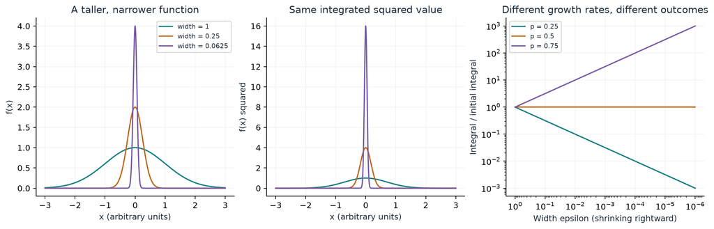

Figure 1: The first two panels show the smooth bump and its square for three shrinking widths, with p=1/2. Their whole-line squared integrals are equal, although the displayed spatial window is finite. The last panel varies p: the squared integral can decrease, stay fixed, or increase even though every peak grows.

## A vortex has two widths that matter

For a constant-density fluid, kinetic energy is

$$E=\frac{\rho}{2}\int |\mathbf u|^2\,dV.$$

The maximum speed asks how large the velocity becomes at its most intense location. Energy adds the squared speed throughout a region. These are different measurements. In mathematical notation, they correspond to the $L^\infty$ norm and, up to the density factor, the square of the $L^2$ norm.

For a core around a vortex axis, a radial width alone is insufficient. We also need its extent along the axis. Call the two scales $a$ and $b$. In cylindrical coordinates,

$$dV=r\,dr\,d\theta\,dz.$$

Set $r=aR$ and $z=bZ$. Then

$$dV=a^2b\,R\,dR\,d\theta\,dZ.$$

The radial scale appears **twice**: once from $dr$ and once from the factor $r$. The axial scale appears once. For a velocity of the form $U\,\mathbf F(R,\theta,Z)$ with a fixed square-integrable shape,

$$E=\frac{\rho}{2}U^2a^2b
\int |\mathbf F|^2 R\,dR\,d\theta\,dZ.$$

The last integral is a fixed shape factor. Thus the useful estimate is

$$\boxed{E_{\rm core}\ \text{scales like}\ U^2a^2b.}$$

Using $a^3$ would assume equal radial and axial scaling. Using only $a^2$ would omit the shrinking axial extent. Either shortcut can change the conclusion.

## Put in the paper’s scales

The paper writes $\tau=1-t$ for time remaining in its dimensionless variables. Section 2.1 gives

$$a\asymp\tau^{1/2},\qquad
b\asymp\tau^{1/2-h},\qquad
U\asymp\tau^{-1/2-h}.$$

Here $U$ represents the dominant azimuthal or axial speed scale. The radial velocity has a weaker stated scale, $O(\tau^{-1/2})$. The parameter $h$ is small and positive; the introduction gives $h<0.01$, and the detailed construction imposes stronger restrictions. The comparison symbol $\asymp$ leaves fixed multiplicative constants unspecified. [OpenAI, Section 2.1, page 4](https://cdn.openai.com/pdf/32d9f210-8b73-45e0-91bc-82a30aef8a9a/navier-stokes.pdf)

Multiplying the two radial factors and the axial factor gives

$$V_{\rm core}\asymp a^2b\asymp\tau^{3/2-h}.$$

Multiplying by the squared speed then gives

$$\boxed{E_{\rm core}\asymp
\tau^{-1-2h}\tau^{3/2-h}
=\tau^{1/2-3h}.}$$

Because $h<0.01$, the exponent $1/2-3h$ is positive. The energy scale therefore tends to zero as $\tau$ tends to zero. The radial component contributes at most the scale $\tau^{1/2-h}$, which also tends to zero. This explains the core-energy statement on page 4.

For a numerical example, use the limit $h\to0^+$ and compare with a reference stage $\tau_0$. If the remaining time falls to one millionth of its reference value, the model gives:

- The characteristic speed is **1,000 times larger**.
- Each characteristic width is **1,000 times smaller**.
- The characteristic volume is **one billionth** of its reference value.
- The core-energy scale is **one thousandth** of its reference value.

The energy multiplication is easy to check: $1000^2\times10^{-9}=10^{-3}$.

| Time remaining / reference | Speed / reference | Radius / reference | Axial width / reference | Volume / reference | Energy / reference |
| --- | --- | --- | --- | --- | --- |
| 1 | 1 | 1 | 1 | 1 | 1 |
| 0.01 | 10 | 0.1 | 0.1 | 0.001 | 0.1 |
| 0.0001 | 100 | 0.01 | 0.01 | 1e-06 | 0.01 |
| 1e-06 | 1e+03 | 0.001 | 0.001 | 1e-09 | 0.001 |

The table contains ratios, not predictions in metres, seconds, or joules. We use $h=0$ as a limiting example, not as a parameter value realizing the theorem.

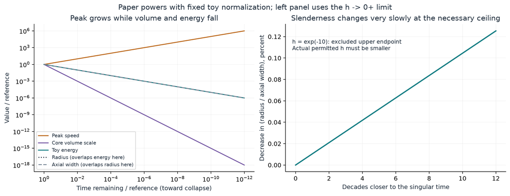

Figure 2: On the left, peak speed increases while volume and energy decrease. Radius, axial width, and energy have the same normalized power in the h=0 limit, so their curves overlap. The right panel shows how small the change in relative slenderness is over a finite time range when using the detailed necessary upper bound on h.

## Does a shrinking core violate incompressibility?

Incompressibility means that a parcel made of the **same fluid particles** preserves its volume. If that parcel is squeezed radially, it must extend in another direction. A region selected because the flow is particularly intense is a different object: particles can enter and leave it.

A simple example makes the distinction concrete. Consider the separate affine velocity field

$$\mathbf v(x,y,z,t)=
\left(-\frac{x}{2\tau},-\frac{y}{2\tau},\frac{z}{\tau}\right),
\qquad \tau=1-t.$$

Its divergence is $-1/(2\tau)-1/(2\tau)+1/\tau=0$. Starting at $\tau_0=1$, the exact trajectories are

$$x=x_0\sqrt{\tau},\qquad
y=y_0\sqrt{\tau},\qquad
z=\frac{z_0}{\tau}.$$

The material volume factor is $\sqrt{\tau}\sqrt{\tau}/\tau=1$. Radial lengths shrink and axial lengths grow.

By comparison, the paper’s intense-flow core has both $a\to0$ and $b\to0$, with the radius shrinking faster when $h>0$. That region is not a material container. In the paper’s central flow, radial inflow and axial outflow are compatible with a shrinking region of intense motion. [OpenAI, Section 2.1 and Figure 1](https://cdn.openai.com/pdf/32d9f210-8b73-45e0-91bc-82a30aef8a9a/navier-stokes.pdf)

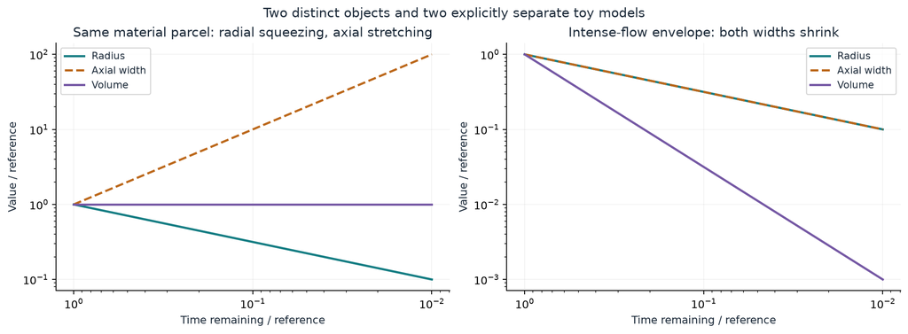

Figure 3: The left panel follows dimensions of the same material parcel in the affine example: radial squeezing is compensated by axial stretching. The right panel follows the prescribed dimensions of an intense-flow envelope, whose volume decreases. These are two separate models, not trajectories computed from the same velocity field.

The affine example is used only for this geometric point. It grows with distance and has infinite whole-space energy; it is not our finite-energy vortex model.

## Watch the concentration in two coordinate systems

For the animation we prescribe a smooth, purely azimuthal toy velocity,

$$u_\theta(r,z,\tau)=U(\tau)\,R
\exp\left(\frac{1-R^2-Z^2}{2}\right),
\qquad R=\frac r{a(\tau)},\quad Z=\frac z{b(\tau)}.$$

Its maximum magnitude is $U$, at $R=1$, $Z=0$, and it vanishes smoothly on the axis. We set the other two velocity components to zero. This field is divergence free and has finite energy at each positive $\tau$. Its time dependence is prescribed; it is not an evaluated profile from the paper and does not reproduce the paper’s radial inflow or axial outflow.

**Open the animation with play, pause, and a frame slider.**

The left panel holds spatial coordinates fixed. The high-speed region becomes smaller while the peak value rises. The right panel divides positions by the current radial and axial widths, and speed by the current peak. In those variables, the shape stays fixed.

The color scales deliberately measure different quantities: the left uses speed relative to the initial peak on a fixed logarithmic scale; the right uses speed relative to the current peak on a fixed linear scale. Playback takes equal steps in the logarithm of time remaining, so movie seconds are not physical seconds. The axes are stretched to fit each panel; their labeled units specify the geometry.

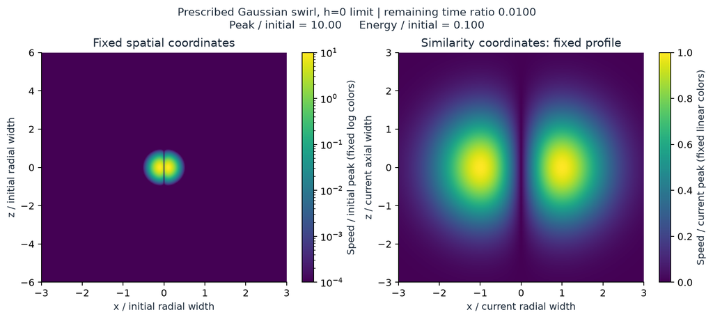

Figure 4: Static final frame of the animation. The time remaining is one hundredth of its reference value, the peak is ten times larger, and the toy energy is one tenth as large. The normalized shape in the right panel has stayed unchanged. The initial axial-to-radial width ratio of two is a toy choice; no material trajectories are shown.

The main animation uses the $h\to0^+$ limit. It shows concentration without an increasing aspect ratio. For the paper’s positive $h$, the ratio $a/b$ has the additional factor $\tau^h$ and eventually tends to zero. Lemma 4.8 implies the necessary bound $h<e^{-10}$, so the visible change over a finite range can be extremely small. A dramatically lengthening-looking schematic would need explicit exaggeration; the right panel of the scaling figure quantifies the small change instead. [OpenAI, Lemma 4.8, page 35](https://cdn.openai.com/pdf/32d9f210-8b73-45e0-91bc-82a30aef8a9a/navier-stokes.pdf)

## What the calculation verifies

The Gaussian vortex has an exact whole-space energy:

$$E_{\rm toy}=\frac{\rho}{2}e\pi^{3/2}U^2a^2b.$$

We independently integrate the same field in Cartesian and cylindrical coordinates. Both agree with the analytic expression. A quadrature refinement study separates integration error from the small omitted Gaussian tail. The notebook records the comparison and lets readers change the scales.

This exact result concerns the **entire Gaussian toy field**. In applying its scaling argument to the paper, we estimate the **leading core contribution**. The paper’s full velocity also includes an exterior, transitions, and corrections. Showing that the leading core energy decreases does not by itself bound those other contributions or prove Theorem 1.1.

What we needed was the speed scale and all three spatial scale factors. What makes the mechanism work is concentration: the volume carrying the largest speeds decreases fast enough to outweigh the growth of speed squared. The computation verifies that balance for explicit smooth examples and reproduces the paper’s stated core-energy exponent.

The next task asks a harder question: what acceleration, pressure, viscosity, and forcing are required to produce a prescribed flow? That is where the momentum residual enters. The source and model notes document the assumptions behind this installment.